Skip to main content

# Data summary of my five flux towers

Author

Paul Eberle

Published

November 25, 2026

**Fork and source on GitHub:** Pau-Rico/datascience_env_monit

## C1. Site overview

The five towers were selected from the latest snapshot file:

```python
print(snapshot_file.name)
```

```
fluxnet_shuttle_snapshot_20261120T104442.csv
```

The half-hourly timestamps are local standard time, as documented by the assignment.

```python
site_table = site_overview[
    [
        "site_id",
        "site_name",
        "country",
        "igbp",
        "location_lat",
        "location_long",
        "first_year",
        "last_year",
        "data_hub",
        "product_citation",
    ]
].rename(
    columns={
        "location_lat": "lat",
        "location_long": "lon",
        "data_hub": "hub",
        "product_citation": "data_citation",
    }
)
site_table
```

Overview of the five selected FLUXNET towers.

|  | site_id | site_name | country | igbp | lat | lon | first_year | last_year | hub | data_citation |
| --- | --- | --- | --- | --- | --- | --- | --- | --- | --- | --- |
| 422 | JP-Ynf | Yona-Field Tower Site | JP | EBF | 26.75100 | 128.212660 | 2013 | 2022 | ICOS | Matsumoto, K., Takashima, A., Taniguchi, S. (2... |
| 542 | BE-Bra | Brasschaat | BE | ENF | 51.30761 | 4.519840 | 1999 | 2025 | ICOS | Janssens, I., Bresseleers, S., De Meulder, T.,... |
| 685 | CH-Oe1 | Oensingen grassland | CH | GRA | 47.28583 | 7.731944 | 2002 | 2011 | ICOS | Ammann, C. (2026). Fluxnet Archive Product fro... |
| 200 | US-MN2 | Morris: Corn-Soybean-Wheat with Cover Crops, M... | US | CRO | 45.62700 | -96.127100 | 2017 | 2024 | AmeriFlux | Christina Helseth, Jane Johnson (2026), AmeriF... |
| 756 | AU-TTE | Ti Tree East | AU | SAV | -22.28700 | 133.640000 | 2012 | 2025 | TERN | Griebel, A., Lieff, N. (2026): Ti Tree East FL... |

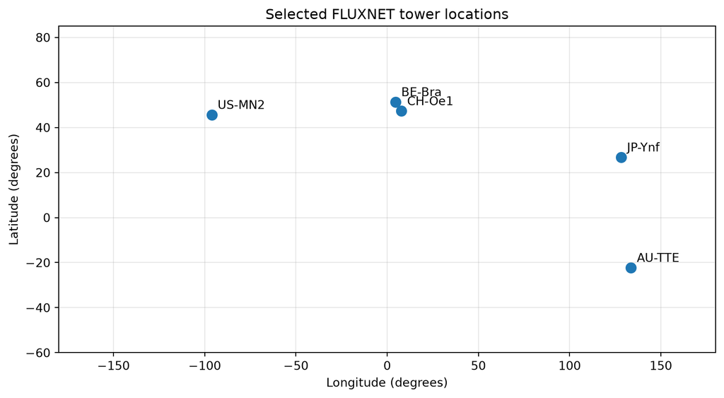

Locations of the five selected FLUXNET towers.

```python
fig, ax = plt.subplots(figsize=(10, 5))
ax.scatter(
    site_overview["location_long"],
    site_overview["location_lat"],
    s=70,
    color="tab:blue",
)
for row in site_overview.itertuples():
    ax.annotate(
        row.site_id,
        (row.location_long, row.location_lat),
        xytext=(5, 5),
                textcoords="offset points")
ax.set(
    xlim=(-180, 180),
    ylim=(-60, 85),
    xlabel="Longitude (degrees)",
    ylabel="Latitude (degrees)",
    title="Selected FLUXNET tower locations",
)
ax.grid(True, alpha=0.3)
plt.show()
```

## C2. Data coverage

The measured fraction is the share of half-hours with `NEE_VUT_REF_QC == 0`. Missing values and quality-control flags are not counted as measured. AU-TTE has no usable VUT reference NEE values, so its coverage check uses `NEE_CUT_REF_QC == 0`.

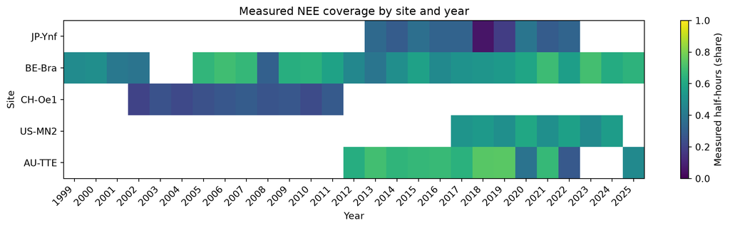

Share of half-hours with measured NEE for each site and year.

```python
fig, ax = plt.subplots(figsize=(12, 3.5))
image = ax.imshow(
    coverage_matrix.to_numpy(),
    aspect="auto",
    interpolation="nearest",
    vmin=0,
    vmax=1,
    cmap="viridis",
)
ax.set(
    xticks=range(len(coverage_matrix.columns)),
    xticklabels=coverage_matrix.columns,
    yticks=range(len(coverage_matrix.index)),
    yticklabels=coverage_matrix.index,
    xlabel="Year",
    ylabel="Site",
    title="Measured NEE coverage by site and year",
)
plt.setp(ax.get_xticklabels(), rotation=45, ha="right")
colorbar = fig.colorbar(image, ax=ax)
colorbar.set_label("Measured half-hours (share)")
plt.tight_layout()
plt.show()
```

```python
print(
    f"The best coverage occurs at {best['site']} in {int(best['year'])}, "
    f"with {best['share_measured']:.1%} of half-hours measured."
)
```

```
The best coverage occurs at AU-TTE in 2019, with 74.4% of half-hours measured.
```

The ZIP files have continuous half-hour timestamp rows; the gaps below are missing flux values in those rows, not missing chunks from a failed download. QC values 1–3 indicate gap-filled estimates rather than direct measurements. This table lists site-years where some NEE values are actually unavailable.

```python
nee_year_availability = (
    all_hh.groupby(["site", "year"], observed=True)
    .agg(
        half_hours=("NEE_ANALYSIS", "size"),
        available_nee=("NEE_ANALYSIS", "count"),
    )
    .reset_index()
)
nee_year_availability["available_nee_percent"] = (
    100
    * nee_year_availability["available_nee"]
    / nee_year_availability["half_hours"]
)
missing_nee_years = nee_year_availability.loc[
    nee_year_availability["available_nee"] < nee_year_availability["half_hours"],
    ["site", "year", "available_nee_percent"],
].rename(columns={"available_nee_percent": "NEE available (%)"}).reset_index(drop=True)
missing_nee_years["NEE available (%)"] = missing_nee_years[
    "NEE available (%)"
].round(1)
missing_nee_years
```

Site-years with missing NEE reference values.

|  | site | year | NEE available (%) |
| --- | --- | --- | --- |
| 0 | AU-TTE | 2012 | 50.2 |
| 1 | AU-TTE | 2020 | 20.8 |
| 2 | AU-TTE | 2022 | 13.4 |
| 3 | AU-TTE | 2023 | 0.0 |
| 4 | AU-TTE | 2024 | 0.0 |
| 5 | AU-TTE | 2025 | 69.8 |
| 6 | BE-Bra | 2001 | 96.4 |
| 7 | BE-Bra | 2003 | 0.0 |
| 8 | BE-Bra | 2004 | 0.0 |
| 9 | BE-Bra | 2008 | 32.8 |
| 10 | JP-Ynf | 2013 | 57.6 |
| 11 | JP-Ynf | 2018 | 77.0 |
| 12 | JP-Ynf | 2019 | 21.8 |
| 13 | JP-Ynf | 2021 | 84.7 |
| 14 | US-MN2 | 2017 | 60.9 |

## C3. Summary statistics

The table reports the variables used for the data summary. The missing percentage is calculated from the half-hourly records. For `P_F`, the mean column is the mean annual precipitation sum rather than the mean half-hour value. `GPP_NT` and `RECO_NT` are the nighttime-partitioned products; no separate daytime partitioning was used. VUT reference products are used where supplied; AU-TTE uses the corresponding CUT reference products because its VUT carbon series are empty.

```python
summary_variables = {
    "TA_F": "TA_F (deg C)",
    "SW_IN_F": "SW_IN_F (W m-2)",
    "VPD_F": "VPD_F (kPa)",
    "P_F": "P_F (mm; annual sum)",
    "NEE_ANALYSIS": "NEE reference (VUT; CUT for AU-TTE; umol CO2 m-2 s-1)",
    "GPP_NT_ANALYSIS": "GPP_NT reference (VUT; CUT for AU-TTE; umol CO2 m-2 s-1)",
    "RECO_NT_ANALYSIS": "RECO_NT reference (VUT; CUT for AU-TTE; umol CO2 m-2 s-1)",
    "H_F_MDS": "H_F_MDS (W m-2)",
    "LE_F_MDS": "LE_F_MDS (W m-2)",
}

summary_rows = []
for site, site_data in all_hh.groupby("site", sort=False):
    for variable, label in summary_variables.items():
        values = site_data[variable]
        mean_value = values.mean()
        if variable == "P_F":
            annual_sum = (
                site_data.groupby("year", observed=True)[variable]
                .sum(min_count=1)
            )
            mean_value = annual_sum.mean()
        summary_rows.append(
            {
                "site": site,
                "variable": label,
                "mean_or_annual_sum": mean_value,
                "minimum": values.min(),
                "maximum": values.max(),
                "missing_percent": values.isna().mean() * 100,
            }
        )

summary_table = pd.DataFrame(summary_rows).round(
    {"mean_or_annual_sum": 3, "minimum": 3, "maximum": 3, "missing_percent": 1}
)
summary_table
```

Summary statistics for the selected half-hourly variables.

|  | site | variable | mean_or_annual_sum | minimum | maximum | missing_percent |
| --- | --- | --- | --- | --- | --- | --- |
| 0 | US-MN2 | TA_F (deg C) | 6.597 | -35.605 | 37.953 | 0.0 |
| 1 | US-MN2 | SW_IN_F (W m-2) | 165.321 | 0.000 | 1066.440 | 0.0 |
| 2 | US-MN2 | VPD_F (kPa) | 3.736 | 0.000 | 53.366 | 0.0 |
| 3 | US-MN2 | P_F (mm; annual sum) | 454.457 | 0.000 | 32.004 | 0.0 |
| 4 | US-MN2 | NEE reference (VUT; CUT for AU-TTE; umol CO2 m... | -0.260 | -73.181 | 49.630 | 4.9 |
| 5 | US-MN2 | GPP_NT reference (VUT; CUT for AU-TTE; umol CO... | 2.745 | -47.946 | 75.887 | 4.9 |
| 6 | US-MN2 | RECO_NT reference (VUT; CUT for AU-TTE; umol C... | 2.485 | 0.000 | 14.704 | 4.9 |
| 7 | US-MN2 | H_F_MDS (W m-2) | 13.301 | -165.003 | 385.139 | 4.9 |
| 8 | US-MN2 | LE_F_MDS (W m-2) | 39.976 | -198.480 | 695.121 | 4.9 |
| 9 | CH-Oe1 | TA_F (deg C) | 9.296 | -17.370 | 35.240 | 0.0 |
| 10 | CH-Oe1 | SW_IN_F (W m-2) | 137.267 | 0.000 | 1113.000 | 0.0 |
| 11 | CH-Oe1 | VPD_F (kPa) | 3.219 | 0.000 | 47.101 | 0.0 |
| 12 | CH-Oe1 | P_F (mm; annual sum) | 1146.318 | 0.000 | 34.807 | 0.0 |
| 13 | CH-Oe1 | NEE reference (VUT; CUT for AU-TTE; umol CO2 m... | -0.818 | -43.906 | 21.768 | 0.0 |
| 14 | CH-Oe1 | GPP_NT reference (VUT; CUT for AU-TTE; umol CO... | 5.353 | -15.051 | 51.697 | 0.0 |
| 15 | CH-Oe1 | RECO_NT reference (VUT; CUT for AU-TTE; umol C... | 4.535 | 0.070 | 20.525 | 0.0 |
| 16 | CH-Oe1 | H_F_MDS (W m-2) | 2.847 | -236.880 | 297.535 | 0.0 |
| 17 | CH-Oe1 | LE_F_MDS (W m-2) | 48.912 | -165.508 | 506.654 | 0.0 |
| 18 | BE-Bra | TA_F (deg C) | 11.091 | -14.120 | 48.060 | 0.0 |
| 19 | BE-Bra | SW_IN_F (W m-2) | 120.796 | 0.000 | 1036.110 | 0.0 |
| 20 | BE-Bra | VPD_F (kPa) | 3.775 | 0.000 | 60.105 | 0.0 |
| 21 | BE-Bra | P_F (mm; annual sum) | 827.929 | 0.000 | 27.600 | 0.0 |
| 22 | BE-Bra | NEE reference (VUT; CUT for AU-TTE; umol CO2 m... | -0.375 | -79.930 | 49.988 | 10.0 |
| 23 | BE-Bra | GPP_NT reference (VUT; CUT for AU-TTE; umol CO... | 4.000 | -49.792 | 83.685 | 10.0 |
| 24 | BE-Bra | RECO_NT reference (VUT; CUT for AU-TTE; umol C... | 3.628 | 0.000 | 13.734 | 10.0 |
| 25 | BE-Bra | H_F_MDS (W m-2) | 18.955 | -297.862 | 991.499 | 7.4 |
| 26 | BE-Bra | LE_F_MDS (W m-2) | 26.920 | -244.605 | 908.554 | 7.4 |
| 27 | JP-Ynf | TA_F (deg C) | 20.960 | 4.747 | 31.417 | 0.0 |
| 28 | JP-Ynf | SW_IN_F (W m-2) | 158.347 | 0.000 | 1213.970 | 0.0 |
| 29 | JP-Ynf | VPD_F (kPa) | 4.509 | 0.000 | 23.839 | 0.0 |
| 30 | JP-Ynf | P_F (mm; annual sum) | 7277.530 | 0.000 | 41.928 | 0.0 |
| 31 | JP-Ynf | NEE reference (VUT; CUT for AU-TTE; umol CO2 m... | -1.025 | -72.317 | 34.238 | 15.9 |
| 32 | JP-Ynf | GPP_NT reference (VUT; CUT for AU-TTE; umol CO... | 5.885 | -28.731 | 76.444 | 23.6 |
| 33 | JP-Ynf | RECO_NT reference (VUT; CUT for AU-TTE; umol C... | 4.787 | 0.000 | 13.394 | 23.6 |
| 34 | JP-Ynf | H_F_MDS (W m-2) | 3.816 | -299.830 | 499.250 | 12.7 |
| 35 | JP-Ynf | LE_F_MDS (W m-2) | 65.464 | -199.703 | 799.012 | 13.4 |
| 36 | AU-TTE | TA_F (deg C) | 23.422 | -261.442 | 44.300 | 0.0 |
| 37 | AU-TTE | SW_IN_F (W m-2) | 254.719 | 0.000 | 1282.000 | 0.0 |
| 38 | AU-TTE | VPD_F (kPa) | 22.739 | 0.299 | 85.456 | 0.0 |
| 39 | AU-TTE | P_F (mm; annual sum) | 314.610 | 0.000 | 41.400 | 0.0 |
| 40 | AU-TTE | NEE reference (VUT; CUT for AU-TTE; umol CO2 m... | 0.048 | -53.468 | 46.084 | 31.9 |
| 41 | AU-TTE | GPP_NT reference (VUT; CUT for AU-TTE; umol CO... | 0.622 | -44.001 | 55.259 | 32.8 |
| 42 | AU-TTE | RECO_NT reference (VUT; CUT for AU-TTE; umol C... | 0.659 | 0.000 | 3.345 | 32.8 |
| 43 | AU-TTE | H_F_MDS (W m-2) | 81.273 | -96.000 | 598.000 | 32.4 |
| 44 | AU-TTE | LE_F_MDS (W m-2) | 20.031 | -98.000 | 594.000 | 32.4 |

## C4. Daily time series

Daily values are calculated as the mean of available half-hourly fluxes. VUT reference products are used where supplied; AU-TTE uses the corresponding CUT reference products. The carbon fluxes are converted from `umol CO2 m-2 s-1` to `g C m-2 d-1` using the assignment factor 1.0378.

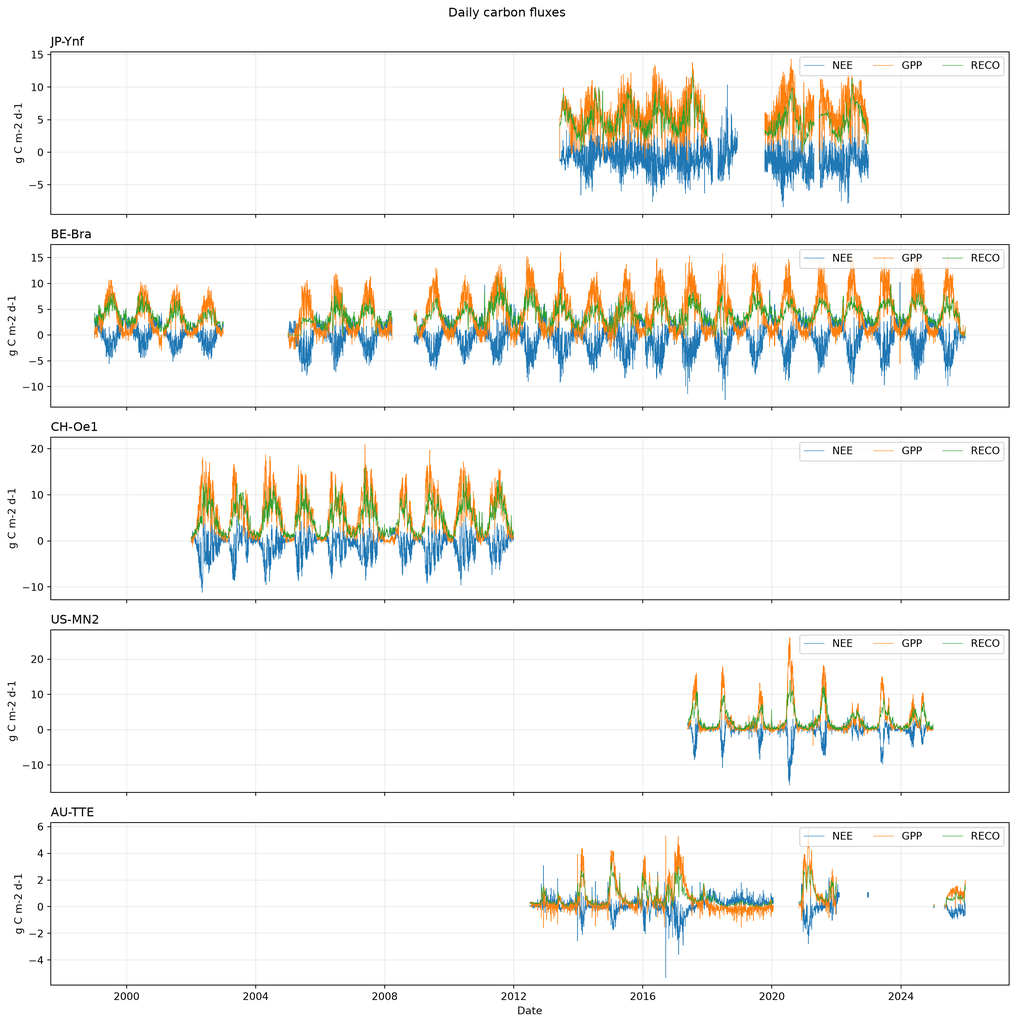

Daily NEE, GPP, and RECO for the five selected towers.

```python
fig, axes = plt.subplots(
    nrows=len(SITE_IDS),
    ncols=1,
    figsize=(14, 14),
    sharex=True,
)
for ax, site in zip(axes, SITE_IDS):
    site_daily = daily_flux[daily_flux["site"] == site]
    for variable, label in [
        ("NEE_ANALYSIS", "NEE"),
        ("GPP_NT_ANALYSIS", "GPP"),
        ("RECO_NT_ANALYSIS", "RECO"),
    ]:
        ax.plot(site_daily["date"], site_daily[variable], label=label, linewidth=0.5)
    ax.set_ylabel("g C m-2 d-1")
    ax.set_title(site, loc="left")
    ax.grid(True, alpha=0.25)
    ax.legend(loc="upper right", ncol=3)
axes[-1].set_xlabel("Date")
fig.suptitle("Daily carbon fluxes", y=0.995)
fig.tight_layout()
plt.show()
```

As a check, the daily aggregation for US-MN2 was compared with its `FLUXMET_DD` file:

```python
us_zip = next((PROJECT_ROOT / "data" / "raw").glob("*_US-MN2_*.zip"))
with zipfile.ZipFile(us_zip) as archive:
    dd_name = next(name for name in archive.namelist() if "FLUXMET_DD" in name)
    with archive.open(dd_name) as source:
        daily_reference = pd.read_csv(
            source,
            na_values=[-9999],
            usecols=lambda column: column in ["TIMESTAMP", *cross_check_variables],
            dtype={"TIMESTAMP": "string"},
        )
daily_reference["date"] = pd.to_datetime(
    daily_reference["TIMESTAMP"], format="%Y%m%d"
)
daily_reference[cross_check_variables] = (
    daily_reference[cross_check_variables] * 1.0378
)
daily_us = daily_flux[daily_flux["site"] == "US-MN2"]
comparison = daily_us.merge(daily_reference, on="date", suffixes=("_from_hh", "_daily"))
for variable in cross_check_variables:
    valid = comparison[[f"{variable}_from_hh", f"{variable}_daily"]].dropna()
    difference = (
        valid[f"{variable}_from_hh"] - valid[f"{variable}_daily"]
    ).abs()
    print(f"{variable}: {len(valid):,} overlapping days; "
          f"maximum absolute difference = {difference.max():.4f}")
```

```
NEE_VUT_REF: 2,779 overlapping days; maximum absolute difference = 0.5916
GPP_NT_VUT_REF: 2,779 overlapping days; maximum absolute difference = 0.9893
RECO_NT_VUT_REF: 2,779 overlapping days; maximum absolute difference = 0.5295
```

## C5. Diurnal cycles

The mean daily course is calculated by local-standard-time hour. Seasons use December-February, March-May, June-August, and September-November. For sites south of the equator, the season names are reversed so that December-February is summer and June-August is winter.

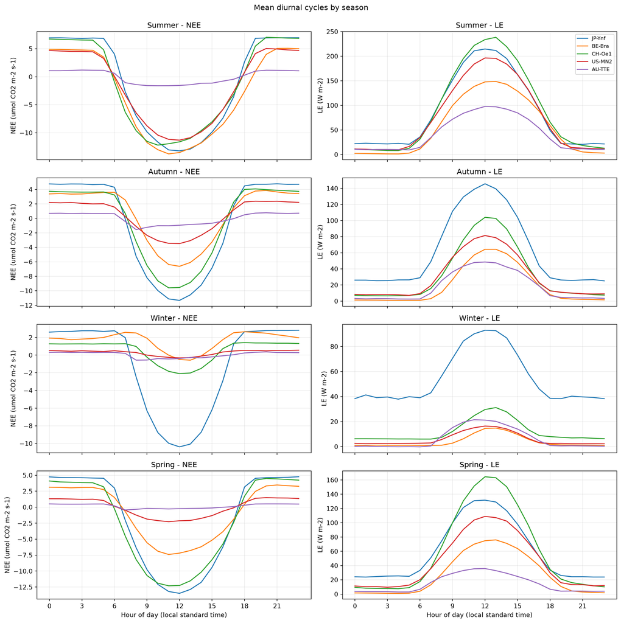

Mean diurnal cycles of NEE and LE by season and site.

```python
seasons = ["summer", "autumn", "winter", "spring"]
diurnal_variables = [
    ("NEE_ANALYSIS", "NEE (umol CO2 m-2 s-1)"),
    ("LE_F_MDS", "LE (W m-2)"),
]
colors = {
    site: plt.cm.tab10(index)
    for index, site in enumerate(SITE_IDS)
}
fig, axes = plt.subplots(
    nrows=len(seasons),
    ncols=len(diurnal_variables),
    figsize=(14, 14),
    sharex=True,
)
for row_index, season in enumerate(seasons):
    season_data = all_hh[all_hh["season"] == season]
    for column_index, (variable, axis_label) in enumerate(diurnal_variables):
        ax = axes[row_index, column_index]
        for site in SITE_IDS:
            means = (
                season_data[season_data["site"] == site]
                .groupby("hour", observed=True)[variable]
                .mean()
            )
            ax.plot(means.index, means.values, label=site, color=colors[site])
        ax.set_title(f"{season.title()} - {variable.split('_')[0]}")
        ax.set_ylabel(axis_label)
        ax.set_xticks(range(0, 24, 3))
        ax.grid(True, alpha=0.25)
        if row_index == len(seasons) - 1:
            ax.set_xlabel("Hour of day (local standard time)")
        if row_index == 0 and column_index == 1:
            ax.legend(loc="upper right", fontsize="small")
fig.suptitle("Mean diurnal cycles by season", y=0.995)
fig.tight_layout()
plt.show()
```

## C6. My reading

### Energy balance

For the energy-balance check, only half-hours with measured H and LE (`H_F_MDS_QC == 0` and `LE_F_MDS_QC == 0`) are used. The tower with the most valid energy-balance observations is selected automatically.

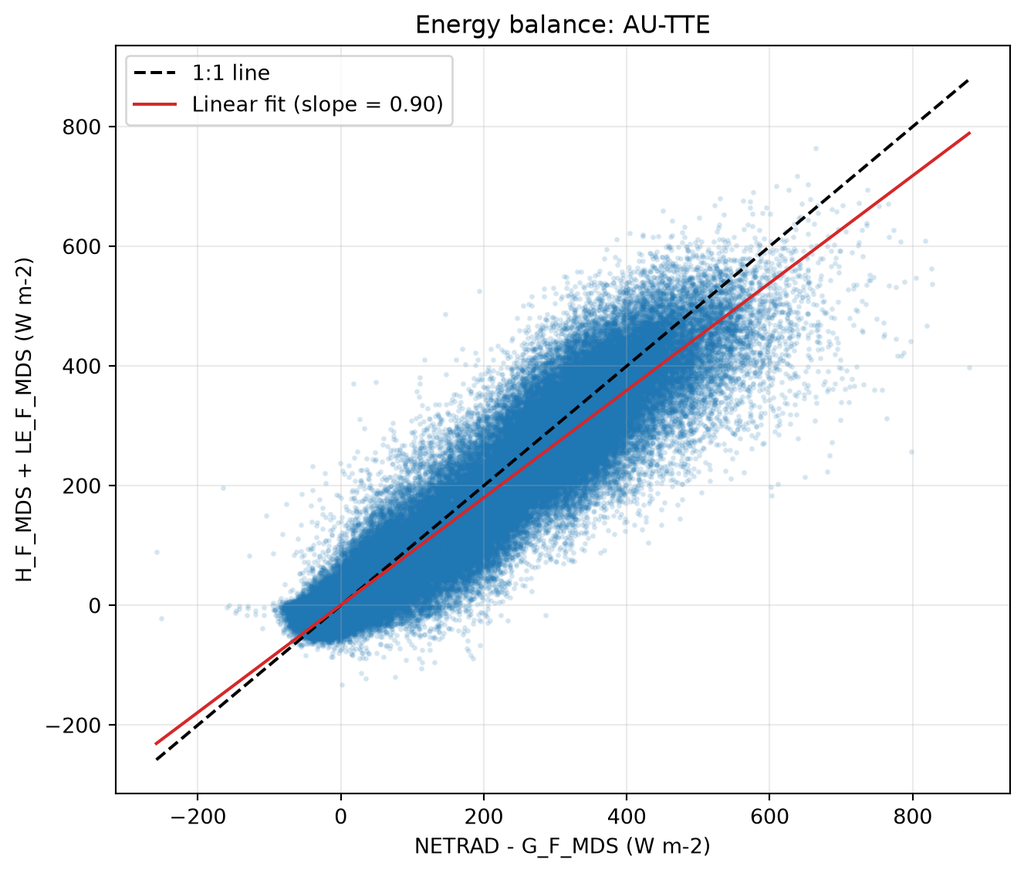

Energy balance for the tower with the most valid QC-filtered observations.

```python
x = energy_site_data["available_energy"]
y = energy_site_data["turbulent_energy"]
line_limits = [min(x.min(), y.min()), max(x.max(), y.max())]
fig, ax = plt.subplots(figsize=(7, 6))
ax.scatter(x, y, s=3, alpha=0.12, color="tab:blue", rasterized=True)
ax.plot(line_limits, line_limits, color="black", linestyle="--", label="1:1 line")
ax.plot(
    line_limits,
    energy_intercept + energy_slope * np.array(line_limits),
    color="tab:red",
    label=f"Linear fit (slope = {energy_slope:.2f})",
)
ax.set(
    xlabel="NETRAD - G_F_MDS (W m-2)",
    ylabel="H_F_MDS + LE_F_MDS (W m-2)",
    title=f"Energy balance: {energy_site}",
)
ax.legend()
ax.grid(True, alpha=0.25)
plt.tight_layout()
plt.show()
```

### Comparison of the five towers

```python
annual_gpp = (
    daily_flux.assign(year=daily_flux["date"].dt.year)
    .groupby(["site", "year"], observed=True)["GPP_NT_ANALYSIS"]
    .sum(min_count=1)
    .groupby("site", observed=True)
    .mean()
)
daily_with_seasons = daily_flux.copy()
daily_with_seasons["month"] = daily_with_seasons["date"].dt.month
daily_with_seasons["season"] = [
    (southern_seasons if site_latitudes[site] < 0 else northern_seasons)[month]
    for site, month in zip(
        daily_with_seasons["site"], daily_with_seasons["month"]
    )
]
seasonal_gpp = (
    daily_with_seasons.groupby(["site", "season"], observed=True)[
        "GPP_NT_ANALYSIS"
    ]
    .mean()
)
seasonal_range = seasonal_gpp.groupby("site", observed=True).agg(
    lambda values: values.max() - values.min()
)
mean_measured = coverage.groupby("site", observed=True)["share_measured"].mean()
gap_filled = 1 - mean_measured

highest_uptake_site = annual_gpp.idxmax()
largest_cycle_site = seasonal_range.idxmax()
most_gap_filled_site = gap_filled.idxmax()
least_gap_filled_site = gap_filled.idxmin()

from IPython.display import Markdown, display

display(
    Markdown(
        " ".join(
            [
                f"Using daily GPP as the carbon-uptake measure, {highest_uptake_site} "
                f"has the largest mean annual uptake at "
                f"{annual_gpp[highest_uptake_site]:.1f} g C m-2 yr-1.",
                f"The largest seasonal cycle in mean daily GPP occurs at "
                f"{largest_cycle_site}, with a seasonal range of "
                f"{seasonal_range[largest_cycle_site]:.2f} g C m-2 d-1.",
                f"{least_gap_filled_site} has the smallest average gap-filled "
                f"fraction ({gap_filled[least_gap_filled_site]:.1%}).",
                f"The result that surprised me most was the large gap-filled "
                f"fraction at {most_gap_filled_site} "
                f"({gap_filled[most_gap_filled_site]:.1%}).",
                "The towers represent forest, grassland, cropland, and wetland "
                "ecosystems, so differences in carbon uptake and seasonality are "
                "expected.",
                "VUT_REF products are used where available; AU-TTE uses the "
                "corresponding CUT_REF products because its VUT carbon columns "
                "are empty. QC flags distinguish measured from gap-filled values.",
            ]
        )
    )
)
```

[output not shown]

## Data and citation

The five site-specific data products and their citations are listed below. The files are from the ONEFlux v1.3 2026 release and were downloaded with the FLUXNET Shuttle from AmeriFlux, the ICOS Carbon Portal, and TERN under the CC-BY-4.0 licence.

```python
site_overview[["site_id", "fluxnet_product_name", "product_citation"]].rename(
    columns={
        "fluxnet_product_name": "downloaded_product_file",
        "product_citation": "citation",
    }
)
```

Citations for the five site-specific FLUXNET data products.

|  | site_id | downloaded_product_file | citation |
| --- | --- | --- | --- |
| 422 | JP-Ynf | JPF_JP-Ynf_FLUXNET_2013-2022_v1.3_r1.zip | Matsumoto, K., Takashima, A., Taniguchi, S. (2... |
| 542 | BE-Bra | ICOS_BE-Bra_FLUXNET_1999-2025_v1.3_r1.zip | Janssens, I., Bresseleers, S., De Meulder, T.,... |
| 685 | CH-Oe1 | EUF_CH-Oe1_FLUXNET_2002-2011_v1.3_r1.zip | Ammann, C. (2026). Fluxnet Archive Product fro... |
| 200 | US-MN2 | AMF_US-MN2_FLUXNET_2017-2024_v1.3_r1.zip | Christina Helseth, Jane Johnson (2026), AmeriF... |
| 756 | AU-TTE | TERN_AU-TTE_FLUXNET_2012-2025_v1.3_r1.zip | Griebel, A., Lieff, N. (2026): Ti Tree East FL... |

I also cite Pastorello et al. (2020), *Scientific Data* 7, 225: https://doi.org/10.1038/s41597-020-0534-3.

> FLUXNET data products were produced and harmonized by eddy covariance regional networks and data processing centers, including AmeriFlux, ChinaFlux, European Fluxes Database, ICOS, JapanFlux, KoFlux, OzFlux, SAEON, and TERN. These products also include a modified version of ERA5 hourly data provided by the Copernicus Climate Change Service.